# Project1 Slides

3/6/2020

## Analysis of Global nCoV Over Time

Can We Predict the End of the Pandemic?

This dataset is updated daily with globally reported cases of the nCoV virus. We plot this data in various ways to determine if the nCoV spread is following a predictable pattern. The 2020 Summer Olympics is scheduled to start in Tokyo on July 24. We will develop a simple model to see if the nCoV cases in China will have subsided by then.

Data Source: https://www.kaggle.com/sudalairajkumar/novel-corona-virus-2019-dataset

## Assumptions

Note:The original data had multiple observations for some dates. In these cases, we will only consider the latest observation for that date. This is valid since these are always increasing quantities.

The ncov dataset has 3 columns for observation counts: Confirmed, Recovered, Deaths It is not clear from the data if Recovered cases are counted in Confirmed. It looks like Confirmed cases are ever-increasing so I will assume a “Recovered” patient is also “Confirmed”. This will allow us to see a downward trend in cases in the future.

## Confirmed Cases of nCoV

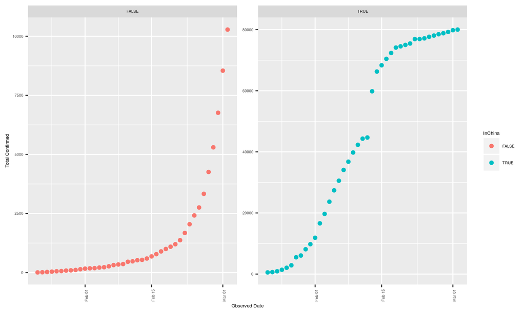

Shows increase in cases inside China is slowing. Outside of China, we cannot see this.

## Recovered Cases of nCoV

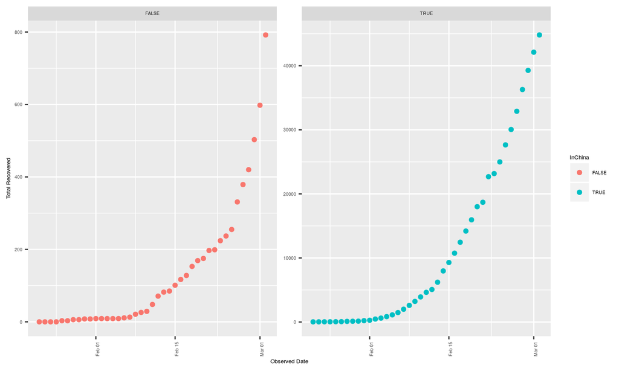

Good news here. The patients are recovering. This number is increasing exponential, at a similar rate to the original spread.

## R-norm

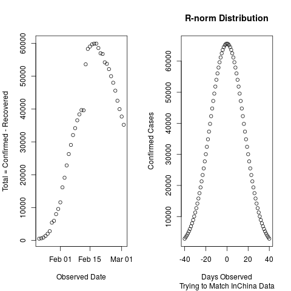

Compare China with Rnorm

We try to construct an R-normal bell curve that matches the nCoV pattern. Virus such as SARS and the Flu typically follow a bell curve.

## Conclusion

Our plots show that the nCoV virus follows the typical pattern of spread associated with a corona virus such as SARs or MERs. If we assume that the slowdown in recent cases in China means that a peak is being reached, the virus will subside in about 40 days. The Olympics are on July 24, 2020, 140 days from now. With a 100 days to spare, hopefully the rest of the world will be better as well.

If the peak is further on, by 2 weeks, for example, add 2 weeks to the 40 days to re-calculate the end of nCoV…this year.